# Problema1: Entender os salários de profissionais de TI no Brasil.

Tales Pimentel

15-10-2014

## Questão(1)

Rosling expôs graficamente dados sociais e de renda. Observando-os há 40 anos atrás se percebe que o mundo ocidental norte é mais rico que as demais regiões do planeta. Tais dados permanecem assim, porém com menos discrepância no início do século XXI. Contudo, quando se considera países isolados, se nota que há alguns que possuem dados financeiros e sociais mais elevados que os da região de origem e comparáveis aos países da OECD.

Os profissionais catalogados podem ser compreendidos em três grandes grupos: concursados, iniciativa privada e outros.

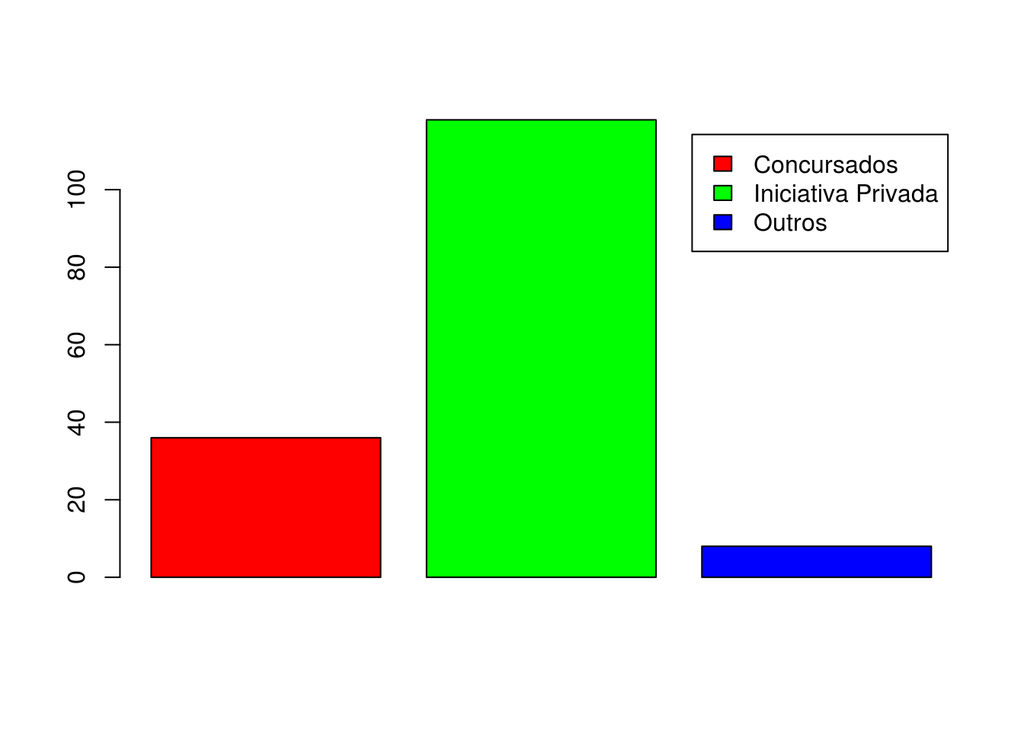

```r
dados = read.csv("../data/salarios-ti-regioes.csv")
concursados = dados[dados$Iniciativa.Privada.ou.Concursado == "Concursado",]
inic_privada = dados[dados$Iniciativa.Privada.ou.Concursado == "Iniciativa Privada",]
outros = dados[dados$Iniciativa.Privada.ou.Concursado != "Iniciativa Privada" & dados$Iniciativa.Privada.ou.Concursado != "Concursado",]

barplot(c(nrow(concursados), nrow(inic_privada), nrow(outros)), legend = c("Concursados", "Iniciativa Privada", "Outros"), col = c("red", "green", "blue"))
```

As remunerações de cada grupo possuem distribuições diferentes. Os da Iniciativa Privada estão quase igualmente distribuidos entre R$1000 e R$6000 com um pico de R$2000 a R$3000. Os Concursados estão com um pouco de concentração de R$3000 até R$6000 Obs.: Para melhor visualização do histograma, em Iniciativa Privada, uma instância de saĺario atípico foi removida. Em Concursados, 3 ocorrências foram removidas pelo mesmo motivo.

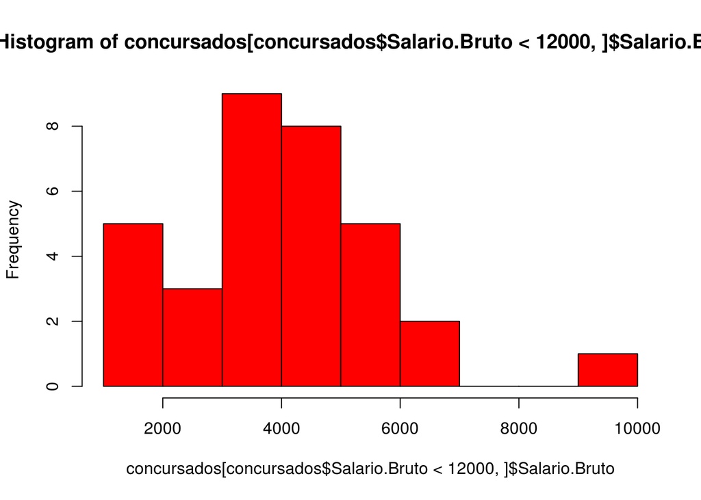

```r
hist(concursados[concursados$Salario.Bruto < 12000,]$Salario.Bruto, col = "red", nclass = 10)
```

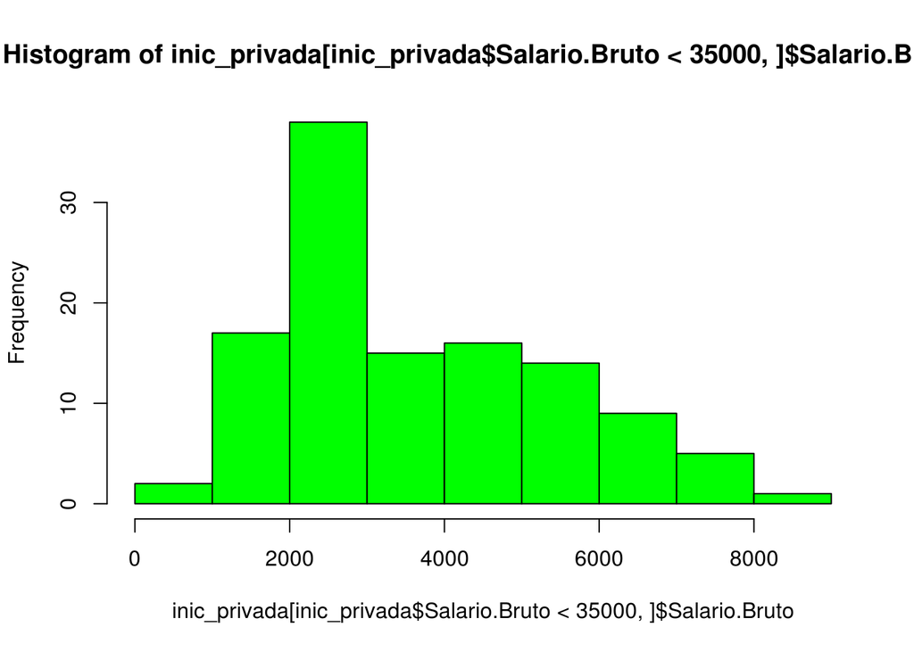

```r
hist(inic_privada[inic_privada$Salario.Bruto < 35000,]$Salario.Bruto, col = "green", nclass = 10)
```

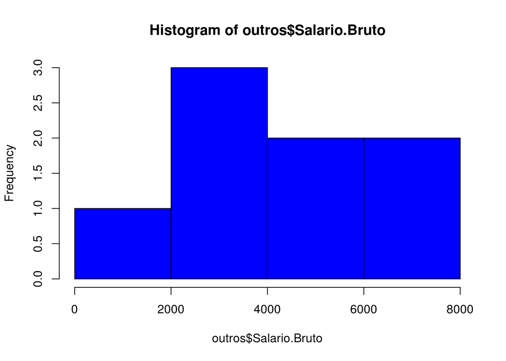

```r
hist(outros$Salario.Bruto, col = "blue")
```

De fato eu esperava um ou mais picos de concentração de remuneração e os demais valores espalhados. Valores atípicos também eram esperados.

Percebe-se que o ranking das regiões por média é diferente do ranking de regiões por mediana. Por um motivo óbvio, a mediana é menos sensível à presença de valores extremos enquanto que a média sim. E nesta coleção, há consideráveis instâncias atípicas.

```r
regiaoNE = c("MA","PI","CE","RN","PB","PE","AL","SE","BA")
regiaoCO = c("DF","GO","MS","MT")
regiaoSE = c("RJ","SP","MG","ES")
regiaoSL = c("RS","SC","PR")
regiaoNO = c("PA","AC","AM","RR","RO","TO","AP")
mNE = mean(dados[is.element(dados$UF, regiaoNE),]$Salario.Bruto)
mCO = mean(dados[is.element(dados$UF, regiaoCO),]$Salario.Bruto)
mSE = mean(dados[is.element(dados$UF, regiaoSE),]$Salario.Bruto)
mSL = mean(dados[is.element(dados$UF, regiaoSL),]$Salario.Bruto)
mNO = mean(dados[is.element(dados$UF, regiaoNO),]$Salario.Bruto)

tabelaRegM = data.frame("regiao" = c("Nordeste", "Centro-oeste", "Sudeste", "Sul", "Norte"), "media" = c(mNE, mCO, mSE, mSL, mNO) )
tabelaRegM = tabelaRegM[with(tabelaRegM, order(-tabelaRegM$media)), ]
rownames(tabelaRegM) = NULL
print(tabelaRegM)
```

```
##         regiao    media
## 1 Centro-oeste 5620.474
## 2     Nordeste 4565.706
## 3      Sudeste 3962.227
## 4          Sul 3657.538
## 5        Norte 2552.500
```

```r
mdNE = median(dados[is.element(dados$UF, regiaoNE),]$Salario.Bruto)
mdCO = median(dados[is.element(dados$UF, regiaoCO),]$Salario.Bruto)
mdSE = median(dados[is.element(dados$UF, regiaoSE),]$Salario.Bruto)
mdSL = median(dados[is.element(dados$UF, regiaoSL),]$Salario.Bruto)
mdNO = median(dados[is.element(dados$UF, regiaoNO),]$Salario.Bruto)
tabelaRegMD = data.frame("regiao" = c("Nordeste", "Centro-oeste", "Sudeste", "Sul", "Norte"), "mediana" = c(mdNE, mdCO, mdSE, mdSL, mdNO) )
tabelaRegMD = tabelaRegMD[with(tabelaRegMD, order(-tabelaRegMD$mediana)), ]
rownames(tabelaRegMD) = NULL
print(tabelaRegMD)
```

```
##         regiao mediana
## 1 Centro-oeste 5000.00
## 2      Sudeste 3582.95
## 3          Sul 3500.00
## 4     Nordeste 2900.00
## 5        Norte 2552.50
```

Caso ele se considere muito ruim recomendaria Sul pois possui o melhor pior caso. Caso contrário (meio ruim, medio, bom e muito bom) , Centro-oeste.

```r
print(summary(dados[is.element(dados$UF, regiaoNE),]$Salario.Bruto))
```

```
##    Min. 1st Qu.  Median    Mean 3rd Qu.    Max.
##     700    2018    2900    4566    4600   42120
```

```r
print(summary(dados[is.element(dados$UF, regiaoNO),]$Salario.Bruto))
```

```
##    Min. 1st Qu.  Median    Mean 3rd Qu.    Max.
##    1105    1829    2552    2552    3276    4000
```

```r
print(summary(dados[is.element(dados$UF, regiaoSE),]$Salario.Bruto))
```

```
##    Min. 1st Qu.  Median    Mean 3rd Qu.    Max.
##     500    2294    3583    3962    5500    9500
```

```r
print(summary(dados[is.element(dados$UF, regiaoSL),]$Salario.Bruto))
```

```
##    Min. 1st Qu.  Median    Mean 3rd Qu.    Max.
##    1800    3100    3500    3658    4500    5495
```

```r
print(summary(dados[is.element(dados$UF, regiaoCO),]$Salario.Bruto))
```

```
##    Min. 1st Qu.  Median    Mean 3rd Qu.    Max.
##    1200    3995    5000    5620    6300   15000
```